# STAT540 - Project 3 - Option 1

2025-11-23

```r
# load the packages for graphing tree and data wrangling
# install.packages("name_of_missing_package")  # uncomment to install package as necessary
library(mdsr)
library(tidyverse)
library(discrim)
library(kknn)
library(dplyr)
library(tidyr)
library(partykit)
library(parsnip)
library(rpart)
```

# Project Objectives?

Study the Diabetes status of people as recorded in the NHANES data using **supervised machine** learning algorithms. Decision tree classifier is built as a base model to compare with at least **two** (**2**) more classifiers.

## Load the Data

### Motivation: Example: **National Health and Nutrition Examination Survey (NHANES)**

A researcher wants to study the risk factors of diabetes in patients. She has available data from the `NHANES` survey data from 2009-2012.

**Some history:** This is survey data collected by the US National Center for Health Statistics (NCHS) which has conducted a series of health and nutrition surveys since the early 1960’s. Since 1999 approximately 5,000 individuals of all ages are interviewed in their homes every year and complete the health examination component of the survey. The health examination is conducted in a mobile examination centre (MEC).

`NHANES` data include `75` variables available for the `2009-2010` and `2011-2012` sample years. NHANESraw has 20,293 observations of these variables plus four additional variables that describe that sample weighting scheme employed. `NHANES` can be treated, for educational purposes, as if it were a **simple random sample** from the American population (the target population).

A full list of the variables can be reviewed for each year survey at [NHANES survey](https://wwwn.cdc.gov/nchs/nhanes/default.aspx)

For full survey data refer to [NHANES CDC.gov](https://wwwn.cdc.gov/nchs/nhanes/Default.aspx)

Look at some records of data for only four variables: `Gender`,`Age`,`BMI`,`Diabetes`

|  | Gender | Age | BMI | Diabetes |
| --- | --- | --- | --- | --- |
| 30 | male | 44 | 31.43 | Yes |
| 31 | female | 64 | 27.18 | Yes |
| 32 | female | 26 | 21.00 | No |
| 33 | female | 59 | 25.79 | Yes |
| 34 | female | 59 | 25.79 | Yes |
| 35 | male | 49 | 29.13 | No |
| 36 | female | 51 | 30.60 | No |
| 37 | female | 51 | 30.60 | No |
| 38 | male | 17 | 23.34 | No |
| 39 | male | 12 | 22.85 | No |

> Let us select one patient with **`ID=207`** who has diabetes for illustration purposes later on, use the variables `Age`, `Gender`, `Diabetes`, `BMI`, `HHIncome`, `PhysActive`.

Note the `Age` and `BMI`.

```r
patient7 <- NHANES[207, c("Age", "Gender", "Diabetes", "BMI", "HHIncome", "PhysActive")]

patient7
```

[output not shown]

Glimpse at the full data:

|  | ID | SurveyYr | Gender | Age | AgeDecade | AgeMonths | Race1 | Race3 | Education | MaritalStatus | HHIncome | HHIncomeMid | Poverty | HomeRooms | HomeOwn | Work | Weight | Length | HeadCirc | Height | BMI | BMICatUnder20yrs | BMI_WHO | Pulse | BPSysAve | BPDiaAve | BPSys1 | BPDia1 | BPSys2 | … |
| --- | --- | --- | --- | --- | --- | --- | --- | --- | --- | --- | --- | --- | --- | --- | --- | --- | --- | --- | --- | --- | --- | --- | --- | --- | --- | --- | --- | --- | --- | --- |
| 1 | 51624 | 2009_10 | male | 34 | 30-39 | 409 | White | NA | High School | Married | 25000-34999 | 30000 | 1.36 | 6 | Own | NotWorking | 87.4 | NA | NA | 164.7 | 32.22 | NA | 30.0_plus | 70 | 113 | 85 | 114 | 88 | 114 | … |
| 2 | 51624 | 2009_10 | male | 34 | 30-39 | 409 | White | NA | High School | Married | 25000-34999 | 30000 | 1.36 | 6 | Own | NotWorking | 87.4 | NA | NA | 164.7 | 32.22 | NA | 30.0_plus | 70 | 113 | 85 | 114 | 88 | 114 | … |
| 3 | 51624 | 2009_10 | male | 34 | 30-39 | 409 | White | NA | High School | Married | 25000-34999 | 30000 | 1.36 | 6 | Own | NotWorking | 87.4 | NA | NA | 164.7 | 32.22 | NA | 30.0_plus | 70 | 113 | 85 | 114 | 88 | 114 | … |
| 4 | 51625 | 2009_10 | male | 4 | 0-9 | 49 | Other | NA | NA | NA | 20000-24999 | 22500 | 1.07 | 9 | Own | NA | 17.0 | NA | NA | 105.4 | 15.30 | NA | 12.0_18.5 | NA | NA | NA | NA | NA | NA | … |
| 5 | 51630 | 2009_10 | female | 49 | 40-49 | 596 | White | NA | Some College | LivePartner | 35000-44999 | 40000 | 1.91 | 5 | Rent | NotWorking | 86.7 | NA | NA | 168.4 | 30.57 | NA | 30.0_plus | 86 | 112 | 75 | 118 | 82 | 108 | … |
| 6 | 51638 | 2009_10 | male | 9 | 0-9 | 115 | White | NA | NA | NA | 75000-99999 | 87500 | 1.84 | 6 | Rent | NA | 29.8 | NA | NA | 133.1 | 16.82 | NA | 12.0_18.5 | 82 | 86 | 47 | 84 | 50 | 84 | … |

Briefly describe the data set.

## Part 1 (5 pts)

Define a subset from the `NHANES` data for the variable `Age`, `Gender`, `Diabetes`, `BMI`, `HHIncome`, `PhysActive` called `people` by dropping the `NA` value

**Solution**:

```r
# complete the code
library(NHANES)
library(dplyr)   # <-- add this
library(tidyr)   # for drop_na()

people <- NHANES %>%
  select(Age, Gender, Diabetes, BMI, HHIncome, PhysActive) %>%
  drop_na()

glimpse(people)
```

```
Rows: 7,555
Columns: 6
$ Age        <int> 34, 34, 34, 49, 45, 45, 45, 66, 58, 54, 58, 50, 33, 60, 56, 56, 54, 54, 38, 36, 44, 44, 64, 26, 59, 59, 51, 51, 17, 12, 12, 16, 16, 16,…
$ Gender     <fct> male, male, male, female, female, female, female, male, male, male, female, male, male, male, female, female, male, male, male, male, m…
$ Diabetes   <fct> No, No, No, No, No, No, No, No, No, No, No, No, No, No, No, No, No, No, No, No, Yes, Yes, Yes, No, Yes, Yes, No, No, No, No, No, No, No…
$ BMI        <dbl> 32.22, 32.22, 32.22, 30.57, 27.24, 27.24, 27.24, 23.67, 23.69, 26.03, 26.22, 26.60, 28.54, 25.84, 19.73, 19.73, 36.32, 36.32, 35.84, 25…
$ HHIncome   <fct> 25000-34999, 25000-34999, 25000-34999, 35000-44999, 75000-99999, 75000-99999, 75000-99999, 25000-34999, more 99999, 65000-74999, 75000-…
$ PhysActive <fct> No, No, No, No, Yes, Yes, Yes, Yes, Yes, Yes, Yes, Yes, No, No, Yes, Yes, Yes, Yes, No, Yes, No, No, Yes, Yes, No, No, Yes, Yes, Yes, Y…
```

```r
nrow(people)   # number of observations
```

```
[1] 7555
```

How many observations are in the data set?

**Answer:** 7555

## Part 2 (5 pts)

Let us write code to see how many people present in the data have diabetes. Create a variable `pcn` and store the result in a date frame object named `DiabetesFreq`.

Hint: Use group_by() function on `Diabetes` variable and then `count()`.

**Solution**:

```r
DiabetesFreq <- people %>%
  group_by(Diabetes) %>%
  count() %>%
  mutate(pct = n / nrow(people))

DiabetesFreq
```

| Diabetes | n | pct |
| --- | --- | --- |
| No | 6871 | 0.90946393 |
| Yes | 684 | 0.09053607 |

We see around 9% of the people in the sample have diabetes.

## Part 3 (5 pts)

Build a decision tree classifier using all of the variables except for `HHIncome` (household income).

**Solution**:

```r
library(rpart)
library(parsnip)

mod_diabetes <- decision_tree(mode = "classification") %>%
  set_engine(
    "rpart",
    control = rpart.control(cp = 0.005, minbucket = 30)
  ) %>%
  fit(Diabetes ~ Age + BMI + Gender + PhysActive, data = people)


mod_diabetes # model saved in this variable
```

```
parsnip model object

n= 7555

node), split, n, loss, yval, (yprob)
      * denotes terminal node

 1) root 7555 684 No (0.90946393 0.09053607)
   2) Age< 52.5 5092 188 No (0.96307934 0.03692066) *
   3) Age>=52.5 2463 496 No (0.79861957 0.20138043)
     6) BMI< 39.985 2301 416 No (0.81920904 0.18079096) *
     7) BMI>=39.985 162  80 No (0.50617284 0.49382716)
      14) Age>=67.5 50  18 No (0.64000000 0.36000000) *
      15) Age< 67.5 112  50 Yes (0.44642857 0.55357143)
        30) Age< 60.5 71  30 No (0.57746479 0.42253521) *
        31) Age>=60.5 41   9 Yes (0.21951220 0.78048780) *
```

## Part 4 (5 pts)

Plot the fitted tree model from **part 3)**.

**Solution**:

[figure not shown]

```r
library(partykit)
plot(as.party(mod_diabetes$fit))
```

If someone is 52 or younger, then it is likely that they do not have diabetes. However, if someone is 53 or older, risk is higher. If BMI is above 40—indicating obesity—then the risk increases again. Strangely—and this may be an evidence of overfitting—the risk is highest if you are between 61 and 67 years old.

## Part 5 (5 pts)

The graph below is a nice way to visualize a complex model. It has plotted our data in two quantitative dimensions (`Age` and `BMI` which are nodes in the decision tree model) while using color to represent our binary response variable (`Diabetes`).

The decision tree simply partitions this two-dimensional space into axis-parallel rectangles. The model makes the same prediction for all observations within each rectangle. It is not hard to imagine—although it is hard to draw—how this recursive partitioning will scale to higher dimensions.

This graph is a clear illustration of the strengths and weaknesses of models based on recursive partitioning. These types of models can only produce axis-parallel rectangles in which all points in each rectangle receive the same prediction. This makes these models relatively easy to understand and apply, but it is not hard to imagine a situation in which they might perform miserably (e.g., what if the relationship was non-linear?).

**Solution**:

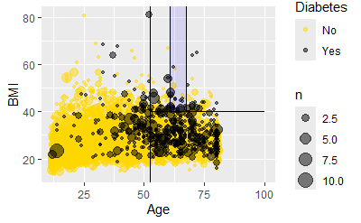

```r
library(tidyverse)
segments <- tribble(
  ~Age, ~xend, ~BMI, ~yend,
  52.5, 100, 39.985, 39.985,
  67.5, 67.5, 39.985, Inf,
  60.5, 60.5, 39.985, Inf
)

ggplot(data = people, aes(x = Age, y = BMI)) +
  geom_count(aes(color = Diabetes), alpha = 0.5) +
  geom_vline(xintercept = 52.5) +
  geom_segment(
    data = segments,
    aes(xend = xend, yend = yend)
  ) +
  scale_fill_gradient(low = "white", high = "red") +
  scale_color_manual(values = c("gold", "black")) +
  annotate(
    "rect", fill = "blue", alpha = 0.1,
    xmin = 60.5, xmax = 67.5, ymin = 39.985, ymax = Inf
  )
```

```r
NA
NA
```

## Part 6 (5 pts)

Run the code to produce the confusion matrix for the decision tree model saved in `mod_diabetes`. Use the entire data `people` as a test set. Note that this is not very good practice as the tree model was trained on it and it should perform fairly well.

**Solution**:

```r
library(yardstick)

pred <- people %>%
  dplyr::select(Diabetes) %>%
  bind_cols(
    predict(mod_diabetes, new_data = people, type = "class")
  ) %>%
  rename(Diabetes_dtree = .pred_class)

confusion <- pred %>%
  conf_mat(truth = Diabetes, estimate = Diabetes_dtree)

confusion
```

```
          Truth
Prediction   No  Yes
       No  6862  652
       Yes    9   32
```

Discuss the output. What are the True Positive (TP), True Negative (TN), False Positive (FP), and False Negative (FN).

**Answer:** In this confusion matrix, the model correctly identifies 6862 people without diabetes (true negatives) and 32 people with diabetes (true positives). It incorrectly labels 9 non-diabetic people as having diabetes (false positives) and misses 652 people who actually have diabetes (false negatives).

## Part 7 (5 pts)

The code below will produce the accuracy of the decision tree model from **part 6)**.

```r
accuracy(pred, Diabetes, Diabetes_dtree)
```

| .metric | .estimator | .estimate |
| --- | --- | --- |
| accuracy | binary | 0.9125083 |

## Part 8 (5 pts)

**Solution**:

```r
library(dplyr)

# pick out the patient with ID = 7 (row 7)
patient7 <- people %>%
  slice(7)

new_x <- patient7

# using the derived tree model saved in mod_diabetes
predict(object = mod_diabetes, new_data = new_x, type = "class")
```

| .pred_class |
| --- |
| No |

```r
NA
```

Was the prediction correct? Discuss, again, the tree model based on the graph from **part 5)** Yes, the prediction was correct: for patient 7 the tree predicts “No” for diabetes, and the actual Diabetes value in the data is also “No.” On the Part 5 graph, this patient falls in the large low-risk region of the plot (outside the older, very high-BMI blue rectangle), so the tree’s structure naturally assigns them to the “No diabetes” rectangle, which is consistent with the observed outcome.

## Task 2 & 3

Use at least **two** supervised machine learning algorithms, e.g. **`knn`**, **`Naive Bayes`**, or `logistic regression` to predict `Diabetes` status by training a model and assessing its predictive ability.

### (10 pts) Create Training and Test data sets (80/20 split) from the `people` data.

Based on the needs for the supervised learning algorithms wrangle the date and/or mutate variables.

Allocate a sample of near `80%` of the rows to the `training` data set, with the remaining `20%` set aside as the `testing` (or “hold-out”) data set.

```r
set.seed(540)  # for reproducibility

# total rows
n <- nrow(people)

# indices for about 80% of the data
train_idx <- sample(1:n, size = floor(0.8 * n))

# training and testing data sets
people_train <- people[train_idx, ]
people_test  <- people[-train_idx, ]

# quick check of sizes
nrow(people_train)
```

```
[1] 6044
```

```r
nrow(people_test)
```

```
[1] 1511
```

```r
library(dplyr)

diab_train <- people_train %>%
  count(Diabetes) %>%
  mutate(pct = 100 * n / sum(n))

diab_train
```

| Diabetes | n | pct |
| --- | --- | --- |
| No | 5485 | 90.751158 |
| Yes | 559 | 9.248842 |

```r
# null model accuracy = proportion of majority class
null_accuracy <- max(diab_train$pct)
null_accuracy
```

```
[1] 90.75116
```

What percentage of the sample has diabetes? What is the accuracy of the *null model*? About 9.25% of the training sample has diabetes.

A null model that always predicts “No diabetes” would have an accuracy of about 90.75%.

### (5 pts) Define one model via formula object in `R` for the `Diabetes` outcome variable.

**Note:** May experiment and make adjustments to the selections later in order to improve the model(s) predictive abilities.

```r
form <- as.formula(
  "Diabetes ~ Age + Gender + BMI + HHIncome + PhysActive"
)

form
```

```
Diabetes ~ Age + Gender + BMI + HHIncome + PhysActive
```

### (20 pts) K-Nearest Neighbors

Apply `KNN` for the `people` data predict the Diabetes status

```r
library(kknn)
library(dplyr)

set.seed(540)

# fit KNN on the training data
knn_fit <- train.kknn(
  formula = form,         # Diabetes ~ Age + Gender + BMI + HHIncome + PhysActive
  data    = people_train,
  kmax    = 15,           # try k = 1,...,15
  kernel  = "rectangular"
)

knn_fit   # shows chosen k and CV performance
```

```
Call:
train.kknn(formula = form, data = people_train, kmax = 15, kernel = "rectangular")

Type of response variable: nominal
Minimal misclassification: 0.07528127
Best kernel: rectangular
Best k: 1
```

```r
# get predictions on the TEST set
knn_pred <- predict(knn_fit, newdata = people_test)

knn_results <- people_test %>%
  select(Diabetes) %>%
  mutate(Diabetes_knn = knn_pred)

head(knn_results)
```

| Diabetes | Diabetes_knn |
| --- | --- |
| No | No |
| No | No |
| No | No |
| Yes | Yes |
| No | No |
| No | No |

```r
NA
NA
```

#### (5 pts) Accuracy is

```r
library(yardstick)

accuracy(knn_results,
         truth   = Diabetes,
         estimate = Diabetes_knn)
```

| .metric | .estimator | .estimate |
| --- | --- | --- |
| accuracy | binary | 0.9192588 |

```r
NA
NA
```

### (20 pts) Naive Bayes Classifier

Apply `Naive Bayes classifier` for the `people` data to predict the Diabetes status

```r
library(discrim)
library(dplyr)

# define a Naive Bayes model and fit on the training data
nb_fit <- naive_Bayes(mode = "classification") %>%
  set_engine("klaR") %>%          # engine for Naive Bayes
  fit(form, data = people_train)  # form was defined earlier

nb_fit
```

[output not shown]

[output cut: 254 more lines]

[output not shown]

```r
# predictions on the TEST set
nb_pred <- predict(nb_fit, new_data = people_test)

nb_results <- people_test %>%
  select(Diabetes) %>%
  bind_cols(nb_pred) %>%
  rename(Diabetes_nb = .pred_class)

head(nb_results)
```

| Diabetes | Diabetes_nb |
| --- | --- |
| No | No |
| No | No |
| No | No |
| Yes | No |
| No | No |
| No | No |

```r
NA
```

**Hint:** A na’ıve Bayes classifier is provided in R by the`naive_Bayes()` function from the `discrim` package.

#### (5 pts) Accuracy is

```r
library(yardstick)

accuracy(nb_results,
         truth    = Diabetes,
         estimate = Diabetes_nb)
```

| .metric | .estimator | .estimate |
| --- | --- | --- |
| accuracy | binary | 0.9172733 |

```r
NA
NA
```

### (20 pts) Logistic Regression Classifier

Apply `Logistic Regression classifier` for the `people` data to predict the Diabetes status.

```r
library(dplyr)

# fit logistic regression on TRAINING data
logit_fit <- glm(form, data = people_train, family = binomial)

summary(logit_fit)
```

```
Call:
glm(formula = form, family = binomial, data = people_train)

Coefficients:
                     Estimate Std. Error z value Pr(>|z|)
(Intercept)         -7.819291   0.481040 -16.255  < 2e-16 ***
Age                  0.056045   0.003063  18.297  < 2e-16 ***
Gendermale           0.341148   0.098179   3.475 0.000511 ***
BMI                  0.087865   0.006544  13.428  < 2e-16 ***
HHIncome 5000-9999   0.210088   0.447391   0.470 0.638652
HHIncome10000-14999  0.385808   0.397916   0.970 0.332260
HHIncome15000-19999  0.102599   0.408441   0.251 0.801662
HHIncome20000-24999  0.306203   0.401689   0.762 0.445887
HHIncome25000-34999 -0.106898   0.390232  -0.274 0.784135
HHIncome35000-44999  0.123371   0.389542   0.317 0.751465
HHIncome45000-54999 -0.390460   0.406356  -0.961 0.336612
HHIncome55000-64999  0.060963   0.406151   0.150 0.880685
HHIncome65000-74999 -0.013263   0.407787  -0.033 0.974055
HHIncome75000-99999 -0.152410   0.394693  -0.386 0.699386
HHIncomemore 99999  -0.450746   0.383796  -1.174 0.240218
PhysActiveYes       -0.179296   0.102551  -1.748 0.080402 .
---
Signif. codes:  0 ‘***’ 0.001 ‘**’ 0.01 ‘*’ 0.05 ‘.’ 0.1 ‘ ’ 1

(Dispersion parameter for binomial family taken to be 1)

    Null deviance: 3726.2  on 6043  degrees of freedom
Residual deviance: 3012.9  on 6028  degrees of freedom
AIC: 3044.9

Number of Fisher Scoring iterations: 6
```

```r
# predict on TEST data
logit_prob <- predict(logit_fit, newdata = people_test, type = "response")

# turn probabilities into class labels
logit_pred <- ifelse(logit_prob >= 0.5, "Yes", "No") %>%
  factor(levels = levels(people$Diabetes))

logit_results <- people_test %>%
  select(Diabetes) %>%
  mutate(Diabetes_logit = logit_pred)

head(logit_results)
```

| Diabetes | Diabetes_logit |
| --- | --- |
| No | No |
| No | No |
| No | No |
| Yes | No |
| No | No |
| No | No |

```r
NA
NA
```

#### (5 pts) Accuracy is

```r
library(yardstick)

accuracy(logit_results,
         truth    = Diabetes,
         estimate = Diabetes_logit)
```

| .metric | .estimator | .estimate |
| --- | --- | --- |
| accuracy | binary | 0.9159497 |

```r
NA
NA
```

#### (5 pts) Compare two of the two classifier using their accuracy.

Using the test set, the Naive Bayes classifier has an accuracy of about **91.7%**, while the logistic regression classifier has an accuracy of about **91.6%**. Naive Bayes is therefore *slightly* more accurate, but both models perform very similarly and only modestly better than the null model accuracy of about **90.8%**.